# Testing Statistical Hypotheses

Stat 241

Let’s start with an example.

**Example 1** Carol’s Cereal Company has been accused of under filling (on average) its 20 oz boxes of toasted oats. The evidence: A sample of 100 boxes produced an average weight of 19.9 oz with a standard deviation of 0.5 oz.

How strong is the evidence?

- Assuming the true average really is 20 oz, what is the probability that a random sample of 100 boxes will average under 20 oz?
- Assuming the true average really is 20 oz, what is the probability that a random sample of 100 boxes will average under 19.9 oz?
- What should we conclude?

$$\begin{align*}
\overline{X} & \approx {\sf Norm}(20, \sigma / \sqrt{100}) \\
\frac{\overline{X} - 20}{\sigma / \sqrt{100}} & \approx {\sf Norm}(0, 1) \\
\frac{\overline{X} - 20}{0.5 / \sqrt{100}} & \approx {\sf T}(99) \\
\end{align*}$$

```r
t <- -0.1 / (0.5/sqrt(100))
pt( t, df = 99)
```

```
## [1] 0.0241
```

So…

- If, on average, the boxes were being filled properly ($\mu = 20$), then there is only a 2.4% chance of getting a sample mean as small or smaller than 19.9 oz just by chance.
- That could happen just by chance, but it isn’t very likely. This provides evidence against the hypothesis that the average weight in all boxes is 20 oz.
- We could also compute a confidence interval for the amount of underfilling.

  ```r
  estimate = 0.1
  SE <- 0.5 / sqrt(100); SE
  ```

  ```
  ## [1] 0.05
  ```

  ```r
  tstar <- qt(0.975, df = 99); tstar
  ```

  ```
  ## [1] 1.98
  ```

  ```r
  estimate + c(-1,1) * tstar * SE
  ```

  ```
  ## [1] 0.000789 0.199211
  ```

  - O is not in the interval – so we have evidence that there is some underfilling.
  - The interval is just a bit narrower than (0, 0.2), so the amount of underfilling seems to be between none and 0.2 oz. We have to decide whether that amount of underfilling matters.

## Hypothesis Testing

The example above illustrates the reasoning that goes into something called a **hypothesis test**.

- **hypothesis** – a statement that could be true or false
- **statistical hypothesis** – a hypothesis about a parameter or paramters ($\mu$, $\beta_1$, $p$, etc.)
  - Examples: $\mu > 25$; $\beta_1 = 1$; $p = 1/6$; $\mu_1 - \mu_2 = 0$
- **statistical hypothesis test** – a formal way to assess whether a data set is *consistent with* a particular statistical hypothesis or provides *evidence against* a particular statistical hypothesis.

### Four steps

1. State the null and alternative hypotheses.
   - We are looking to see if there is *evidence against the null hypothesis*.
2. Compute a test statistic.
   - We need to summarize the evidence in our data as a single number, called the test statistic.
3. Determine the p-value
   - p-value = the probability of observing data at least as unusual as the data we have, *assuming the null hypothesis is true*
   - This will be computed using the sampling distribution of the test statistic, *assuming the null hypothesis is true*.
4. Draw a conclusion.

   We have two possible conclusions:
   - **If the p-value is small**, that means our data would be unlikely if the null hypothesis were true. This provides evidence *against the null hypothesis*.
   - **If the p-value is not small**, that means data like our data could happen if the null hypothesis were true, so our data are *consistent with the null hypothesis* hypothesis. That doesn’t mean the null hypothesis is true, only that our data don’t provide enough evidence to reject it.

#### How small is small?

- This depends somewhat on the situation and the consequences of making an error.
- The threshold below which we will reject the null hypothesis is called the **significance level** of a test. It is usually denoted $\alpha$.
- The most common significance level is 0.05; but it is better to report the p-value than to only report whether the p-value is above or below this standard.

| p-value range | what it means |
| --- | --- |
| above 0.1 | Our data are consistent with the null hypothesis. The null hypothesis may not be true, but our data don’t contradict it. |
| 0.05 - 0.10 | Borderline. Some people call this “suggestive”. We might want to collect more data, but the current data aren’t providing enough evidence to reject the null hypothesis. |
| 0.01 - 0.05 | Minimal evidence to reject the null hypothesis. We have evidence, but not overwhelming evidence. Our data would be fairly unusual if the null hypothesis were true. |
| 0.001 - 0.01 | Stronger evidence. Our data would be quite unusual if the null hypothesis were true. |
| smaller | As the p-value gets smaller, the evidence against the null hypothesis becomes stronger. |

### Tests about a population mean ($\mu$)

1. Hypotheses
   - $H_0$: $\mu =$ _______ ($\mu = \mu_0$)
   - Three possible alternatives
     - $H_a$: $\mu \neq \mu_0$
     - $H_a$: $\mu < \mu_0$
     - $H_a$: $\mu > \mu_0$
2. Test Statistic
   - $\displaystyle t = \frac{\overline{x} - \mu_0}{s/\sqrt{n}}$
   - in words: $\displaystyle \frac{ \mbox{data value} - \mbox{hypothesized value}}{SE}$
3. P-value
   - Use `pt()` because $\displaystyle \frac{\overline{X} - \mu}{SE} \approx {\sf T}(\mbox{df})$
   - df = $n - 1$, just like for confidence intervals
4. Draw a conclusion.
   - This step is the same for all tests, once you have the p-value.
1. Hypotheses
   - $H_0$: $\mu = 20$
   - $H_0$: $\mu < 20$
2. Test Statistic
   - $t = \frac{19.9 - 20}{0.5/\sqrt{100}} = -2$
3. P-value
   - `pt(t, df = 99)` = 0.024
4. Draw a conclusion.
   - There is only a 2.4% chance of seeing a sample mean this small if the population mean is actually 20 oz. This gives us evidence against that hypothesis (in favor of underfilling).

### One and two-sided alternatives

Whether we use a 1- or 2-sided alternative depends on what sort of evidence we are looking for. We won’t accuse the cereal company of underfilling the boxes if they have too much cereal in the box, so we have a 1-sided alternative.

**Important:**

- Using a 1-sided test requires justification. When in doubt, do a two-sided test.
- The choice of 1-sided vs 2-sided alternative may never depend on the data. **If you need the data to decide which direction to use, you should be doing a 2-sided test.**

**Example 2** Company A advertises that its gizmo parts have an average diameter of 3.00 cms. Company B purchases these parts from company A and depends on the parts meeting the advertised average diameter. If the average diameter is bigger or smaller than 3.00 cms, it would create a problem. So, Company B tests a random sample of 100 parts. It is willing to accept Company A’s claim unless the sample provides strong evidence that the claim is false.

The sample mean for the 100 parts in the sample is 3.04 cm and the standard deviation is 0.15 cm.

Should the parts be accepted?

```r
t <- (3.04 - 3.0) / (0.15 / sqrt(100)); t
```

```
## [1] 2.67
```

```r
pt(t, df = 99)
```

```
## [1] 0.996
```

```r
1 - pt(t, df = 99)
```

```
## [1] 0.00447
```

```r
2 * (1 - pt(t, df = 99))
```

```
## [1] 0.00895
```

### Tests and Linear Models

We can also perform test about parameters in a model. For example, to test the null hypothesis that $\beta_1 = 0$ in a linear model, we can use

$$t = \frac{ \mbox{data value} - \mbox{hypothesized value}}{SE} =
\frac{\hat \beta_1 - 0}{SE}$$

The summary output from `lm()` provices the values of $\hat \beta_1$ and $SE$, so we have everything we need.

**Example 3** Is the elongation fractions (%) of an alumimum bar related to the volume fraction of oxide in the alloy prior to casting? Test the null hypothesis that $\beta_1 = 0$.

```r
AluminumBars <-
  Devore7::xmp12.12 %>%
  rename(
    oxide = x,
    elongation = y
  )
AluminumBars %>% head(4) %>% pander()
```

| oxide | elongation |
| --- | --- |
| 0.1 | 0.96 |
| 0.16 | 1.1 |
| 0.31 | 0.8 |
| 0.37 | 0.84 |

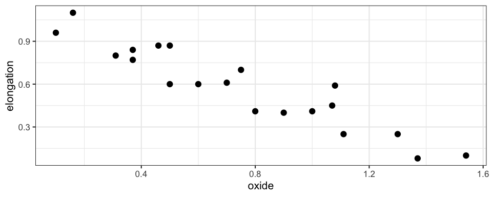

```r
gf_point(elongation ~ oxide, data = AluminumBars)
```

```r
model <- lm(elongation ~ oxide, data = AluminumBars)
msummary(model)
```

```
##             Estimate Std. Error t value Pr(>|t|)
## (Intercept)   1.0693     0.0497    21.5  2.7e-14 ***
## oxide        -0.6488     0.0584   -11.1  1.7e-09 ***
##
## Residual standard error: 0.105 on 18 degrees of freedom
## Multiple R-squared:  0.873,  Adjusted R-squared:  0.866
## F-statistic:  123 on 1 and 18 DF,  p-value: 1.73e-09
```

```r
t <- (-0.649 - 0) / 0.0584; t
```

```
## [1] -11.1
```

```r
2 * pt(t, df = 18)
```

```
## [1] 1.72e-09
```

**Notes**

1. The $t$ statistic and p-value for this test also appear in the summary output. If we want to test a different null hypothesis (like $\beta_1 = 1$, then we need to do the work ourselves using the estimate and standard error provided.
2. This is sometimes called the **model utility test**, because if $\beta_1 = 0$, then our predictions don’t depend on the explanatory variable at all, so our explanatory variable is not useful for predicting the response.
3. This result is consistent with what we learn from a confidence interval for $\beta_1$:

   ```r
   model %>% confint()
   ```

   ```
   ##              2.5 % 97.5 %
   ## (Intercept)  0.965  1.174
   ## oxide       -0.772 -0.526
   ```

   The confidence interval is entirely below 0 (and well separated from 0).

   **The values inside a 95% confidence interval are exactly the ones that we would not reject in a two-sided hypothesis test if we use 0.05 has our significance level.**

## Some Practice

**1.** Test for the alternative hypothesis $\mu < 3.4$ using a sample of size 25 with sample mean is $\overline{x} = 3.3$ and sample standard deviation is $s = 0.7$. Show all four steps.

**2.** Was the average weight of all 1974 automobile models greater than 2900 pounds? Use the data in `mtcars` to test this. Does the data in mtcars provide strong evidence that the average weight for all 1974 models is greater than 2900 pounds?

**3.** The World Health Organization (WHO) has issued a preliminary guideline for lead concentration in drinking water. It states that the average concentration should be at less than 10 $\mu$g/l (micrograms/liter).  
Company A produces drinking water. It must test its water to determine whether it meets the WHO preliminary guideline.

Consider two ways of performing a test:

A. $H_0: \mu = 10$, $H_a: \mu < 10$

B. $H_0: \mu = 10$, $H_a: \mu > 10$

1. What do we conclude if we reject the null hypothesis in A?
2. What do we conclude if we reject the null hypothesis in B?
3. What do we conclude if we fail to reject the null hypothesis in B?
4. What do we conclude if we fail reject the null hypothesis in B?
5. If you were a consumer, which test would you like performed? Why?
6. If you worked for Company A, which test would you like to report? Why?

**4.** The `warpbreaks` data set contains data on the number of warpbreaks per loom, where a loom corresponds to a fixed length of yarn. There are two types of wool (A and B) in this data set. Is there evidence that the two types of wool have a different number of warpbreaks on average?

```r
df_stats(breaks ~ wool, data = warpbreaks) %>% pander()
```

| response | wool | min | Q1 | median | Q3 | max | mean | sd | n | missing |
| --- | --- | --- | --- | --- | --- | --- | --- | --- | --- | --- |
| breaks | A | 10 | 19.5 | 26 | 36 | 70 | 31.04 | 15.85 | 27 | 0 |
| breaks | B | 13 | 18 | 24 | 29 | 44 | 25.26 | 9.301 | 27 | 0 |

Note: this is a new situation, but our general form still applies

$$t = \frac{\mbox{data value} - \mbox{null hypothesis value}}{SE}$$

1. What should you use for data value, null hypothesis value, and SE?
2. Should you do a 1-sided test or a 2-sided test?
3. What p-value do you get? What do you conclude?
4. Check your work using

   ```r
   t.test(breaks ~ wool, data = warpbreaks)
   ```

   Why won’t the results from `t.test()` be exactly the same as what you did by hand?